# A2_Sabbir_Hossain

### Density Curve for Normalized Distribution Values

```r
ctsDenct <- apply(log2(edgeR::cpm(normalized_datastruct[,3:14])), 2, density)
dataplot2 <- c(colnames(samples))

xlim <- 0; ylim <- 0
for (i in 1:length(ctsDenct)) {
  xlim <- range(c(xlim, ctsDenct[[i]]$x));
  ylim <- range(c(ylim, ctsDenct[[i]]$y))
}
cols <- rainbow(length(ctsDenct))
ltys <- rep(1, length(ctsDenct))

plot(ctsDenct[[1]], xlim = xlim, ylim = ylim, type = "n", ylab = "Smoothing density of log2-CPM", main = "Normalized Distribution Values for GSE193417", cex.lab = 0.85)
for (i in 1:length(ctsDenct))
  lines(ctsDenct[[i]], col = cols[i], lty = ltys[i])
```

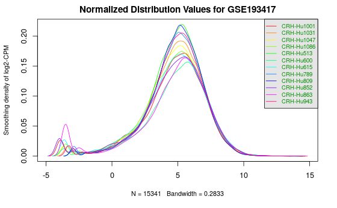

```r
legend("topright", legend = dataplot2, col=cols, lty=ltys, cex=0.75, border="blue", text.col = "green4", merge = TRUE, bg = "gray90")
```

```r
#Remember to add in the figure name, number and description.
```

Figure 2. A normalized distribution curve The density curves are another way to analyse our data before and after the normalisation process; because they are proportional to the size of the data set, they work particularly well with larger data sets. The more data we can add to this curve, the better we’ll be able to predict and model it. While outlines and data that do not match the average are more than likely to affect the extreme ends of the curve, we can still deduce that those who suffer from MDD will find someone with whom they can comfortably align themselves. The more data we can add to this curve, the better we’ll be able to predict and model it. The higher curves for the youngest and oldest of the group in this data set and these samples specifically. While there are a few points where the difference in the variable values mapped against the curve falls short of the non-normalized graph, the normalised graph lacks extra values, repetitions are the most likely culprit because they count for twice as much as they should.

### Normalized Data Strucutre

```r
knitr::kable(t(normalized_datastruct[1:5,]), type="html",)
```

|  | 1 | 2 | 3 | 4 | 5 |
| --- | --- | --- | --- | --- | --- |
| ensembl_gene_id | ENSG00000000003 | ENSG00000000419 | ENSG00000000457 | ENSG00000000460 | ENSG00000000971 |
| hgnc_symbol | TSPAN6 | DPM1 | SCYL3 | C1orf112 | CFH |
| CRH-Hu1001 | 0.000000 | 9.575111 | 0.000000 | 0.000000 | 0.000000 |
| CRH-Hu1031 | 10.657725 | 14.498347 | 46.951601 | 3.168513 | 0.000000 |
| CRH-Hu1047 | 0.6299757 | 0.0000000 | 15.2769115 | 4.0160953 | 11.1820693 |
| CRH-Hu1086 | 0.00000000 | 0.08828009 | 31.16287262 | 2.64840277 | 0.17656018 |
| CRH-Hu513 | 15.561174 | 5.227582 | 45.954092 | 18.965181 | 1.945147 |
| CRH-Hu600 | 11.3993735 | 0.0000000 | 5.4588549 | 0.1605546 | 0.0000000 |
| CRH-Hu615 | 0.000000 | 18.436284 | 58.255289 | 15.994949 | 1.346943 |
| CRH-Hu789 | 8.393148 | 0.000000 | 25.688120 | 37.260491 | 24.670769 |
| CRH-Hu809 | 9.2910323 | 8.1761084 | 0.1238804 | 21.5551949 | 6.1940215 |
| CRH-Hu852 | 0.0000000 | 4.6425067 | 0.8500364 | 13.1428712 | 0.0000000 |
| CRH-Hu863 | 5.491062 | 41.787916 | 31.829548 | 0.000000 | 1.489102 |
| CRH-Hu943 | 0.00000 | 15.83270 | 22.83562 | 21.82071 | 27.80871 |

```r
NA
```

Table 2. A table that shows the completed normalized data structure for this dataset, with matching ensemble gene IDs, and HGNC symbols for each of the samples. This data structure was one of the intended final products of Assignment 1. The object is called normalized_datastruct.

### Differential Gene Expression on Normalized Dataset

```r
design_model <- model.matrix(~ design2$sample_expression)
minimal_set <- ExpressionSet(normalized_counts_pmil)
fit <- limma::lmFit(minimal_set, design_model)
fit2 <- limma::eBayes(fit, trend=TRUE)
topfit <- limma::topTable(fit2, coef=ncol(design_model), adjust.method="BH", number=nrow(normalized_counts_pmil))
# Add the gene symbols
output_hits <- merge(
  data.frame(gene = geneSymID, row.names = rownames(normalized_counts_pmil)),
  topfit,
  by=0,
  all=TRUE
)
# Sort by unadjusted p-value
output_hits <- output_hits[order(output_hits$P.Value, decreasing = FALSE),]
output_hits
```

|  | Row.names | gene.ensembl_gene_id | gene.hgnc_symbol | logFC | AveExpr | t | P.Value | adj.P.Val | B |
| --- | --- | --- | --- | --- | --- | --- | --- | --- | --- |
| 3017 | 12823 | ENSG00000183087 | GAS6 | -85.690230 | 95.146350 | -4.893605 | 6.364642e-05 | 0.9575699 | -4.594784 |
| 10023 | 5068 | ENSG00000125633 | CCDC93 | -69.007096 | 116.734355 | -4.232193 | 3.261230e-04 | 0.9575699 | -4.594835 |
| 7304 | 2568 | ENSG00000103260 | METRN | -28.325229 | 17.490277 | -3.918429 | 7.073046e-04 | 0.9575699 | -4.594862 |
| 13061 | 7882 | ENSG00000147133 | TAF1 | -81.657048 | 148.537583 | -3.862555 | 8.114574e-04 | 0.9575699 | -4.594867 |
| 14016 | 8761 | ENSG00000156076 | WIF1 | -50.018930 | 45.727891 | -3.709526 | 1.180750e-03 | 0.9575699 | -4.594881 |
| 2509 | 12340 | ENSG00000178950 | GAK | -65.472325 | 130.936328 | -3.702667 | 1.200712e-03 | 0.9575699 | -4.594881 |
| 11764 | 6681 | ENSG00000138029 | HADHB | 42.269884 | 27.627149 | 3.650779 | 1.362880e-03 | 0.9575699 | -4.594886 |
| 12123 | 7018 | ENSG00000140386 | SCAPER | 85.231951 | 195.023615 | 3.539054 | 1.788587e-03 | 0.9575699 | -4.594896 |
| 8938 | 407 | ENSG00000023902 | PLEKHO1 | -63.376206 | 100.872728 | -3.522594 | 1.861445e-03 | 0.9575699 | -4.594898 |
| 11154 | 6114 | ENSG00000134644 | PUM1 | 78.423039 | 219.193983 | 3.442957 | 2.257021e-03 | 0.9575699 | -4.594905 |

[output cut: 990 more lines]

Table 3. A table that shows the first 10 genes with the lowest P-values of the dataset. This table is ordered, by the P.value attribute and starts with the lowest P.value and goes to the largest P.value.